# Studies: Online platforms of the University of Lorraine

This University has too many websites!

Nancy

LCT Year 1

Published

November 5, 2021

This university has a bunch of websites for different purposes.

# Sésame: For activating student accounts

[Sésame](https://sesame.univ-lorraine.fr/index) is the website for activating student accounts. After [registering](https://luisavasquez.github.io/quiescens-lct/posts/2021-11-02-registering_university_lorraine.html) as a student at the University of Lorraine, the Administrative Coordinator will send you an email with a code and extra details for activating your email and student account here.

# ENT: An overview board

The [ENT](https://ent.univ-lorraine.fr/) (*Environnment de Travail*, Work Environment) website is supposed to be a hub for all the other websites. In reality, it is visually very saturated:

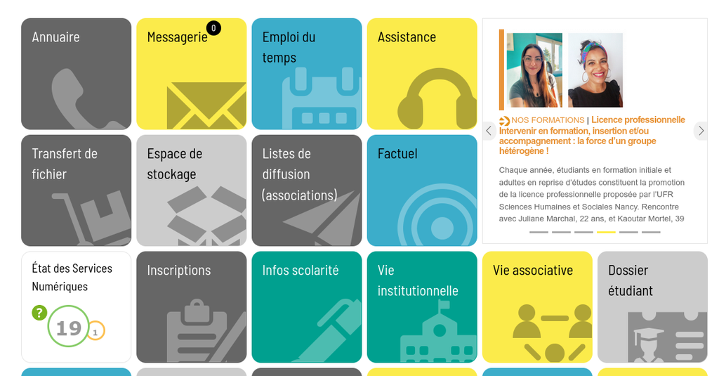

Here I will only mention those websites that are most commonly accessed through the ENT:

## Zimbra: email

[Zimbra](https://mail.etu.univ-lorraine.fr/) is an email client for the accounts of the University of Lorraine. From now on, all interaction with professors and administrative staff is done through here. Available in French and English.

Note that your student account will receive **two email aliases**, a short one based on your last name and a long one based on your full name. Both aliases use the same mailbox. For the major part, logging in to university websites is done with the short alias. I reall don’t know why they do this.

## mULti: Calendar

[mULti](https://multi.univ-lorraine.fr/) is a website with the class schedule for the whole semester. It also tells you the classrooms for the lessons. Available in French.

Note, some courses of the M1-TAL Master’s are shared with students from the Cognitive Science Master at the IDMC. Because of this, their schedule also shows in the mULti. During the first weeks of class, you and your classmates will figure out which lecture is only for you, which is only for Cognitive Science students, and which is shared.

## Dossier étudiant: Grades and Proof of enrollment

The [Dossier étudiant](https://multi.univ-lorraine.fr/) is a website that shows you your status as a student. Available in French.

- Here, you can see your grades in the *Notes & résultats* (Grades and results) tab, as professors upload them.
- You can also download your *Certificat d’éscolarité* (**Proof of enrollment**) in the University of Lorraine. This document will be required for doing most bureaucracy in France as a student. It is available for download in the *inscriptions* (registrations) tab.

# Arche: Courses’s pages and for submitting homework

The [Arche](https://arche.univ-lorraine.fr/) website is where professors will upload slides, PDFs, media files, etc., and where homework can be submitted.

Each course has its own Arche page, and registering is needed to be able to see it. Sometimes the professors will register you automatically, and sometimes they will send a link for everyone to register. In some occassions professors only registered the students of the local Master’s and LCT students had to ask the professors to be registered manually in Arche.

# Suaps: Sport, dance, and outdoor activities

The [suaps](https://suaps-catalogue.univ-lorraine.fr/) lists all recreational and leisure activities from the University of Lorraine. The vast majority of them **are free** for students!

(Some activities have very inconvenient schedules though).

Available in French.

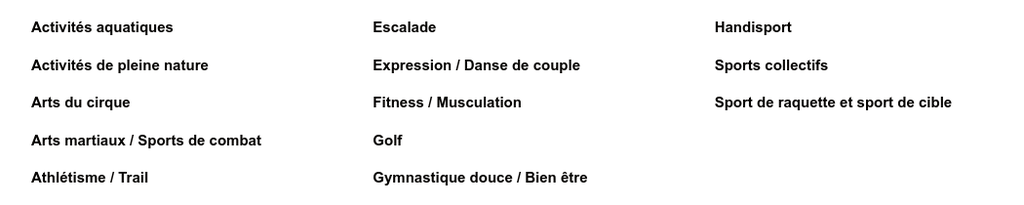

# The University of Lorraine App

The University of Lorraine has a mobile app available called [UNIVLORRAINE](https://www.univ-lorraine.fr/lapplication-mobile-univlorraine/).

The main uses I have for this app are:

- reviewing the mULti calendar
- using student card in QR form, because it is required for many Suaps activities.

Note that many international students had trouble downloading the app, because it is only available in the French Google Play and Apple Stores. The easiest solution was to create a dummy email in France, and use it to download the app.

# The IZLY App

Strictly speaking, the [IZLY](https://www.izly.fr/) app is from CROUS, not from the University of Lorraine.

This app is used for paying with your student card in CROUS stablishments, like cafeterias, supermarkets, and laundry rooms. It is not mandatory to pay using IZLY, but it is very convenient.

The first issues is setting up an IZLY account. For local students, this was done automatically, for LCT students, this did not go so easily.

Normally, an IZLY account is linked to a student account. For some reason, this would not work when creating my IZLY account. I had to create it linked to my French phone number. After this, inside the app, I had to link the account with my student card by providing a special code printed in it.

Finally, to put some money on your student card, you need to have an European bank account. Then, you can pay by either scanning your student card or by generating a QR in the IZLY app.

Due to all of these issues, I could only start using my IZLY account after my second month in France. Meanwhile, I payed by showing my student card and using the bank card I brought from my country.